# Lab 2

- Show All Code
- Hide All Code
- View Source

Author

Leticia Mezzetti

# Set-up

In the code chunk below load in the packages necessary for your analysis. You should only need the tidyverse and here packages for this analysis, unless you decide to use additional resources.

```r
library(tidyverse)
library(here)
```

# Data Context

The Portal Project is a long-term ecological study being conducted near Portal, AZ. Since 1977, the site has been used to study the interactions among rodents, ants and plants and their respective responses to climate. To study the interactions among organisms, we experimentally manipulate access to 24 study plots. This study has produced over 100 scientific papers and is one of the longest running ecological studies in the U.S.

We will be investigating the animal species diversity and weights found within plots at the Portal study site. The dataset is stored as a comma separated value (CSV) file. Each row holds information for a single animal, and the columns represent:

| Column | Description |
| --- | --- |
| record_id | Unique id for the observation |
| month | month of observation |
| day | day of observation |
| year | year of observation |
| plot_id | ID of a particular plot |
| species_id | 2-letter code |
| sex | sex of animal (“M”, “F”) |
| hindfoot_length | length of the hindfoot in mm |
| weight | weight of the animal in grams |
| genus | genus of animal |
| species | species of animal |
| taxon | e.g. Rodent, Reptile, Bird, Rabbit |
| plot_type | type of plot |

### **Question 1**

Using the `read_csv()` function and the **here** package, write the code to load in the `surveys.csv` dataset. For simplicity, store the dataset in an object named `surveys`.

```r
# Code for question 1!
surveys <- read_csv(here("Labs", "Lab 2", "surveys.csv"))
```

## Inspecting the Data

```r
# Code for questions 2 & 3!
##2
dim(surveys)
```

```
[1] 30463    15
```

```r
##3
str(surveys)
```

```
spc_tbl_ [30,463 × 15] (S3: spec_tbl_df/tbl_df/tbl/data.frame)
 $ record_id      : num [1:30463] 63 64 65 66 67 68 69 71 74 75 ...
 $ month          : num [1:30463] 8 8 8 8 8 8 8 8 8 8 ...
 $ day            : num [1:30463] 19 19 19 19 19 19 19 19 19 19 ...
 $ year           : num [1:30463] 1977 1977 1977 1977 1977 ...
 $ plot_id        : num [1:30463] 3 7 4 4 7 8 2 7 8 8 ...
 $ species_id     : chr [1:30463] "DM" "DM" "DM" "DM" ...
 $ sex            : chr [1:30463] "M" "M" "F" "F" ...
 $ hindfoot_length: num [1:30463] 35 37 34 35 35 32 15 36 12 32 ...
 $ weight         : num [1:30463] 40 48 29 46 36 52 8 35 7 22 ...
 $ date           : Date[1:30463], format: "1977-08-19" "1977-08-19" ...
 $ day_of_week    : chr [1:30463] "Fri" "Fri" "Fri" "Fri" ...
 $ plot_type      : chr [1:30463] "Long-term Krat Exclosure" "Rodent Exclosure" "Control" "Control" ...
 $ genus          : chr [1:30463] "Dipodomys" "Dipodomys" "Dipodomys" "Dipodomys" ...
 $ species        : chr [1:30463] "merriami" "merriami" "merriami" "merriami" ...
 $ taxa           : chr [1:30463] "Rodent" "Rodent" "Rodent" "Rodent" ...
 - attr(*, "spec")=
  .. cols(
  ..   record_id = col_double(),
  ..   month = col_double(),
  ..   day = col_double(),
  ..   year = col_double(),
  ..   plot_id = col_double(),
  ..   species_id = col_character(),
  ..   sex = col_character(),
  ..   hindfoot_length = col_double(),
  ..   weight = col_double(),
  ..   date = col_date(format = ""),
  ..   day_of_week = col_character(),
  ..   plot_type = col_character(),
  ..   genus = col_character(),
  ..   species = col_character(),
  ..   taxa = col_character()
  .. )
 - attr(*, "problems")=<externalptr>
```

```r
# taken from: https://www.geeksforgeeks.org/display-the-internal-structure-of-an-object-in-r-programming-str-function/
```

### **Question 2**

What are the dimensions of these data?  
*Hint: Writing code is Step 1. You also need to connect the output of the code to what it tells you about the dimensions of the data.*

- The dimensions of the data are 30463 rows and 15 columns.

### **Question 3**

What are the data types of the variables in the dataset?  
*Hint: Yes, this question requires code. No, you do not need anything complicated.*

## Plotting with **`ggplot2`**

`ggplot()` graphics are built step by step by adding new elements. Adding layers in this fashion allows for extensive flexibility and customization of plots.

To build a `ggplot()`, we will use the following basic template that can be used for different types of plots:

```
ggplot(data = <DATA>, mapping = aes(<VARIABLE MAPPINGS>)) +
   <GEOM_FUNCTION>()
```

Let’s get started!

## Scatterplot

### **Question 4**

First, create a scatterplot of the relationship between `weight` (on the x-axis) and `hindfoot_length` (on the y-axis).

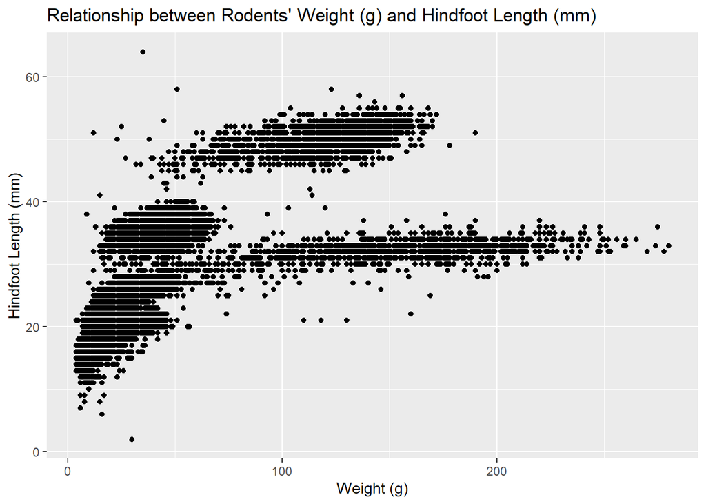

```r
# Code for question 4!
 ggplot(data = surveys,
       mapping = aes(x = weight,
                     y = hindfoot_length)) +
  geom_point() +
  labs(x = "Weight (g)",
       y = "Hindfoot Length (mm)",
       title = "Relationship between Rodents' Weight (g) and Hindfoot Length (mm)")
```

We can see there are **a lot** of points plotted on top of each other. Let’s try and modify this plot to extract more information from it.

### **Question 5**

Add transparency (`alpha`) to the points, to make the points more transparent and (possibly) easier to see.

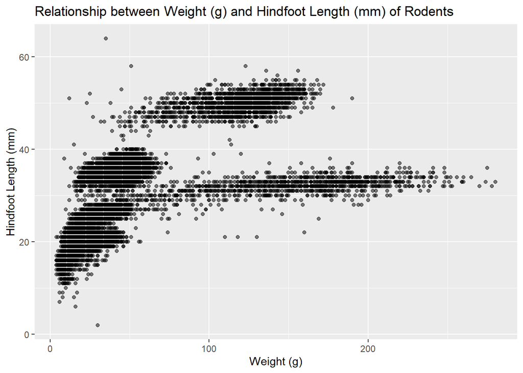

```r
#Code for question 5!
 ggplot(data = surveys,
       mapping = aes(x = weight,
                     y = hindfoot_length)) +
  geom_point(alpha = 0.5) +
  labs(x = "Weight (g)",
       y = "Hindfoot Length (mm)",
       title = "Relationship between Weight (g) and Hindfoot Length (mm) of Rodents")
```

Well, that is better, but there are still large clumps of data being plotted on top of each other. Let’s try another tool!

### **Question 6**

Add some jitter to the points in the scatterplot.  
*Hint: both `geom_point()` and `geom_jitter()` add points to the plot.*

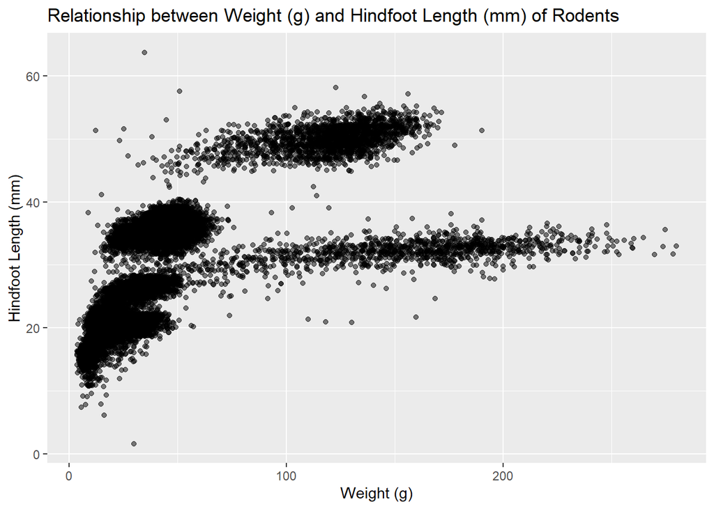

```r
# Code for question 6!
# geom_jitter() is great for plots that have hella points. It spreads them out.
 ggplot(data = surveys,
       mapping = aes(x = weight, y = hindfoot_length)) +
  geom_jitter(alpha = 0.5) +
  labs(x = "Weight (g)",
       y = "Hindfoot Length (mm)",
       title = "Relationship between Weight (g) and Hindfoot Length (mm) of Rodents")
```

## Faceting

Despite our best efforts there is still a substantial amount of overplotting occurring in our scatterplot. Let’s try splitting the dataset into smaller subsets and see if that allows for us to see the trends a bit better.

### **Question 7**

Facet your jittered scatterplot by `species`.

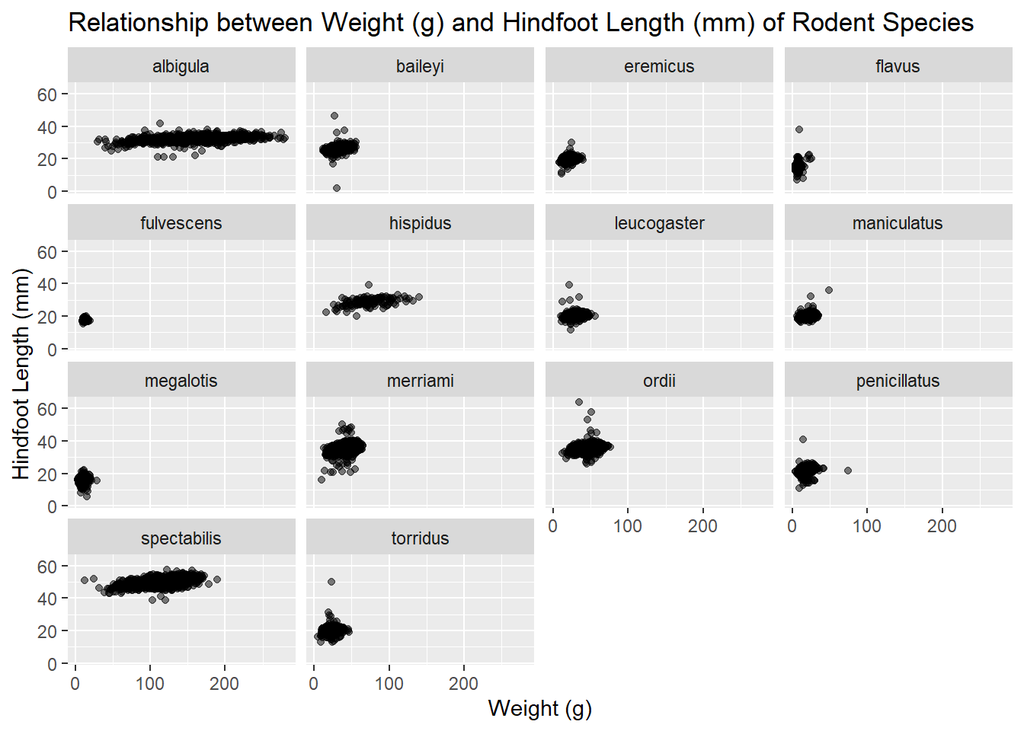

```r
# Code for question 7
 ggplot(data = surveys,
       mapping = aes(x = weight,
                     y = hindfoot_length)) +
  geom_jitter(alpha = 0.5) +
  facet_wrap(~ species) +
  labs(x = "Weight (g)",
       y = "Hindfoot Length (mm)",
       title = "Relationship between Weight (g) and Hindfoot Length (mm) of Rodent Species")
```

# Boxplots & Density Ridges

### **Question 8**

Create side-by-side boxplots to visualize the distribution of weight within each species.

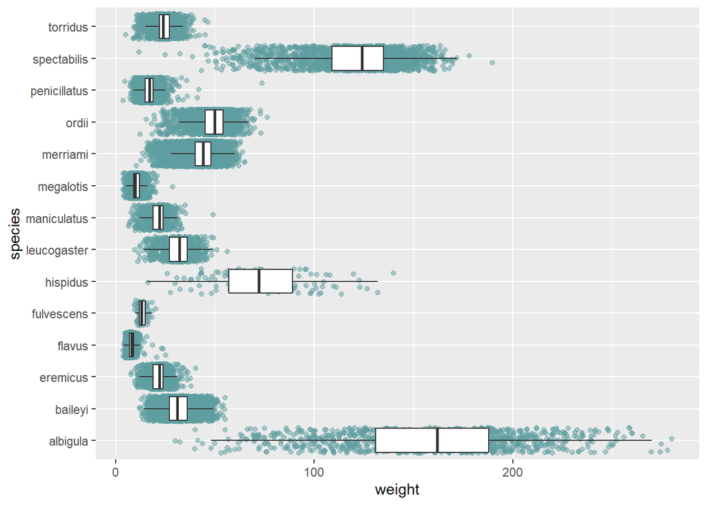

```r
# Code for question 8 (and 9 and 10 and 11 and 12)!)
ggplot(data = surveys,
        mapping = aes(x = weight,
                      y = species)) +
          geom_jitter(alpha = 0.5,
                      color = "cadetblue") +
            geom_boxplot(outlier.shape = NA)
```

A fundamental complaint of boxplots is that they do not plot the raw data. However, with **ggplot** we can add the raw points on top of the boxplots!

### **Question 9**

Add another layer to your previous plot (above) that plots each observation.

Alright, this should look less than optimal. Your points should appear rather stacked on top of each other. To make them less stacked, we need to jitter them a bit, using `geom_jitter()`.

### **Question 10**

Remove the previous layer you had and include a `geom_jitter()` layer.

That should look a bit better! But its really hard to see the points when everything is black.

### **Question 11**

Use the `color` argument in `geom_jitter()` to change the color of the points. You are welcome to use whatever color you wish, some of my favorites are: tomato, cadetblue, and darkseagreen :)

Great! Now that you can see the points, you should notice something odd: there are two colors of points still being plotted. Some of the observations are being plotted twice, once from `geom_boxplot()` as outliers and again from `geom_jitter()`!

### **Question 12**

Inspect the help file for `geom_boxplot()` and see how you can remove the outliers from being plotted by `geom_boxplot()`. Make this change in the code above!

# Customization

Some small changes that make **big** differences to plots. One of these changes are better labels for a plot’s axes and legend.

### **Question 13**

Using the code you created in question 12, modify the x-axis and y-axis labels to describe what is being plotted. Be sure to include any necessary units!

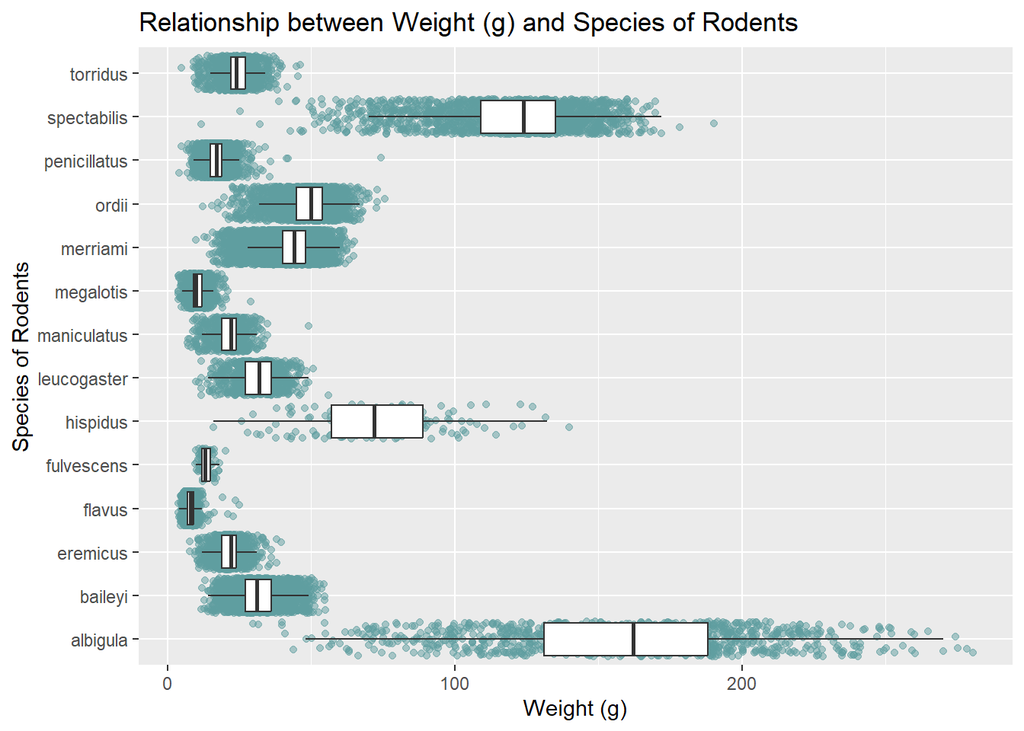

```r
# Code for question 13!
ggplot(data = surveys,
        mapping = aes(x = weight,
                      y = species)) +
          geom_jitter(alpha = 0.5,
                      color = "cadetblue") +
            geom_boxplot(outlier.shape = NA) +
  labs(x = "Weight (g)",
       y = "Species of Rodents",
       title = "Relationship between Weight (g) and Species of Rodents")
```

Some people (and journals) prefer for boxplots to be stacked with a specific orientation! Let’s practice changing the orientation of our boxplots.

### **Question 14**

Flip the orientation of your boxplots from question 10. If you created side-by-side boxplots (stacked horizontally), your boxplots should be stacked vertically. If you had vertically stacked boxplots, you should stack your boxplots horizontally!  
*Hint: You **do not** need to add an additional layer.*

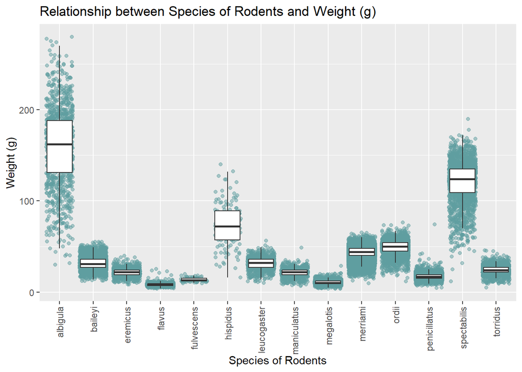

```r
# Code for question 14!
ggplot(data = surveys,
        mapping = aes(x = species,
                      y = weight)) +
          geom_jitter(alpha = 0.5,
                      color = "cadetblue") +
            geom_boxplot(outlier.shape = NA) +
  labs(x = "Species of Rodents",
       y = "Weight (g)",
       title = "Relationship between Species of Rodents and Weight (g)") +
  guides(x = guide_axis(angle = 90))
```

```r
# Added an extra layer to make the labels more readable, but this wasn't necessary for the functionality of this question
# Axis Label Orientation: https://ggplot2.tidyverse.org/reference/guide_axis.html
```